# Module 06 — Extraction, and the four things that verify it

HWC North Africa automated evidence map

2026-08-24

```r
knitr::opts_chunk$set(echo = TRUE, warning = TRUE, message = TRUE, dpi = 300)
suppressPackageStartupMessages({
  library(here); library(dplyr); library(tibble); library(readr)
  library(ggplot2); library(tidyr)
})
source(here::here("R", "config.R"))
OKABE <- c("#E69F00", "#56B4E9", "#009E73", "#F0E442", "#0072B2", "#D55E00", "#CC79A7")
```

```r
man <- readRDS(here::here(DIR_DERIVED, "extraction_manifest.rds"))
ext <- readRDS(here::here(DIR_DERIVED, "extraction_fields.rds"))
rel <- readr::read_csv(here::here(DIR_TABLES, "extraction_reliability.csv"),
                       show_col_types = FALSE)
stopifnot(isTRUE(man$complete))
knitr::kable(man, caption = "Extraction run manifest")
```

Extraction run manifest

| when | limit | n_analytic | n_records | n_calls | n_calls_ok | n_calls_failed | xmodel | model | xmodel_name | complete |
| --- | --- | --- | --- | --- | --- | --- | --- | --- | --- | --- |
| 2026-08-24 03:19:22 | NA | 262 | 260 | 1716 | 1716 | 0 | TRUE | gemma4:e4b | qwen2.5:7b | TRUE |

# 1 What was extracted, and from what

1716 model calls over 260 records completed with 0 failures. Nineteen fields were extracted in three schema-constrained groups; the remaining seven of the protocol’s twenty-six are bibliographic and were carried from OpenAlex metadata rather than re-read off the page, because asking a model to restate a field we already hold exactly would manufacture error where ground truth exists.

```r
eb <- ext |> dplyr::distinct(id, evidence_base, text_source) |>
  dplyr::count(evidence_base, text_source)
knitr::kable(eb, caption = "What text each record was extracted from")
```

What text each record was extracted from

| evidence_base | text_source | n |
| --- | --- | --- |
| full_text | full_body_fallback | 4 |
| full_text | full_body_fallback_truncated | 13 |
| full_text | methods_results | 95 |
| full_text | methods_results_truncated | 4 |
| title_abstract | title_abstract | 144 |

Records with retrievable full text were extracted from the **methods and results sections** of the GROBID TEI; the rest from **title and abstract**. Extracting only from full text would have redefined the map as a map of the open-access subset, which Module 05 showed is not drawn evenly across countries. Every value carries its `evidence_base`, and the reliability figures below are stratified by it.

# 2 The four verification mechanisms

## 2.1 1. Quote-grounding — a directly measured hallucination rate

Every non-null value carries a verbatim quote, string-matched back against the source text after normalising whitespace, case and quotation glyphs. A quote that cannot be found sets the value to `NA` with reason `unverified_quote`.

```r
g <- ext |> dplyr::filter(is_positive) |>
  dplyr::summarise(n = dplyr::n(),
                   grounded = sum(grounded_main %in% TRUE),
                   rate = round(mean(grounded_main %in% TRUE), 4))
knitr::kable(g, caption = "Quote-grounding over positive claims")
```

Quote-grounding over positive claims

| n | grounded | rate |
| --- | --- | --- |
| 1957 | 1871 | 0.9561 |

**95.6% of positive claims were grounded**, so the measured hallucination rate is 4.4%. That is stronger evidence than any spot-check, because it is computed over every value rather than a sample.

Two design decisions shape this number and both cut against flattering it. Quotes joined by an ellipsis are split and **every** segment must match, so a stitched-together citation is not scored as correct. Conversely, values that assert **absence** — `"no"`, `"not measured"`, `"not stated"` — are exempt, because no paper contains a sentence saying “we tested no mitigation”. Grounding measures whether asserted *presence* is real.

```r
gb <- ext |> dplyr::group_by(evidence_base) |>
  dplyr::summarise(positive = sum(is_positive),
                   grounding = round(mean(grounded_main[is_positive] %in% TRUE), 4),
                   .groups = "drop")
knitr::kable(gb, caption = "Grounding by evidence base")
```

Grounding by evidence base

| evidence_base | positive | grounding |
| --- | --- | --- |
| full_text | 755 | 0.9470 |
| title_abstract | 1202 | 0.9617 |

Grounding is essentially identical whether the source was full text or an abstract, which is reassuring: the model is not compensating for a thinner evidence base by inventing more.

## 2.2 2. Self-consistency — measured, not assumed

```r
sc <- ext |> dplyr::filter(is_stated) |>
  dplyr::summarise(n = dplyr::n(),
                   lenient = round(mean(consistent %in% TRUE), 4),
                   strict  = round(mean(consistent_strict %in% TRUE), 4))
knitr::kable(sc, caption = "Agreement between run 1 and run 2")
```

Agreement between run 1 and run 2

| n | lenient | strict |
| --- | --- | --- |
| 2379 | 0.9424 | 0.9248 |

Module 04b reported self-consistency of exactly 1.0000 with zero flips across 60,000 records. That number measured nothing: temperature 0 with a fixed seed is deterministic, so identical inputs must produce identical outputs.

Here run 2 uses a different seed at temperature 0.3, so the two runs *can* differ, and the resulting 0.942 is an actual robustness measurement. This is a deliberate protocol deviation and is recorded as one.

Enum fields are compared exactly; free-text fields also count as agreeing when one run’s value contains the other’s (“jackal” vs “golden jackal”), since a strict string test on free text measures phrasing rather than stability. Both figures are reported — strict is 0.925.

## 2.3 3. Cross-model agreement

A random 20% of records were re-extracted with qwen2.5:7b, a different training lineage from gemma4:e4b.

## 2.4 4. “not stated” everywhere

Every enum carries the escape hatch. Without one the model invents plausible values, and absence is exactly what this map measures.

```r
ab <- ext |> dplyr::filter(is_stated) |>
  dplyr::summarise(stated = dplyr::n(),
                   absence_assertions = sum(!is_positive),
                   pct = round(100 * mean(!is_positive), 1))
knitr::kable(ab, caption = "How often the model asserted absence rather than a value")
```

How often the model asserted absence rather than a value

| stated | absence_assertions | pct |
| --- | --- | --- |
| 2379 | 422 | 17.7 |

# 3 The reliability table

```r
knitr::kable(rel |> dplyr::select(field, kind, n_stated, pct_stated, n_positive,
                                  grounding, self_consist, cross_model, reliable),
             caption = sprintf("Per-field reliability. Fields below %.2f on any measure are excluded from the headline analysis.",
                               FIELD_RELIABILITY_MIN))
```

Per-field reliability. Fields below 0.70 on any measure are excluded from the headline analysis.

| field | kind | n_stated | pct_stated | n_positive | grounding | self_consist | cross_model | reliable |
| --- | --- | --- | --- | --- | --- | --- | --- | --- |
| damage_metric_reported | enum | 202 | 77.7 | 90 | 0.967 | 0.946 | 0.481 | FALSE |
| compensation_scheme_discussed | enum | 140 | 53.8 | 4 | 1.000 | 0.986 | 0.519 | FALSE |
| study_design | enum | 183 | 70.4 | 183 | 0.951 | 0.847 | 0.577 | FALSE |
| subnational_region | free_text | 136 | 52.3 | 136 | 0.956 | 0.956 | 0.654 | FALSE |
| species_scientific | free_text | 126 | 48.5 | 126 | 0.937 | 0.944 | 0.692 | FALSE |
| mitigation_tested | enum | 103 | 39.6 | 38 | 1.000 | 1.000 | 0.731 | TRUE |
| conflict_type | enum | 154 | 59.2 | 154 | 0.974 | 0.922 | 0.750 | TRUE |
| mitigation_outcome_measured | enum | 91 | 35.0 | 28 | 0.964 | 0.989 | 0.750 | TRUE |
| mitigation_type | free_text | 44 | 16.9 | 44 | 0.977 | 0.750 | 0.846 | TRUE |
| outcome_direction | enum | 68 | 26.2 | 24 | 1.000 | 0.956 | 0.769 | TRUE |
| species_common | free_text | 201 | 77.3 | 201 | 0.950 | 0.955 | 0.788 | TRUE |
| stakeholder_engagement | enum | 51 | 19.6 | 49 | 0.959 | 0.922 | 0.788 | TRUE |
| taxonomic_class | enum | 228 | 87.7 | 228 | 0.930 | 0.965 | 0.808 | TRUE |
| damage_estimate | free_text | 40 | 15.4 | 40 | 0.950 | 0.825 | 0.885 | TRUE |
| country | enum | 160 | 61.5 | 160 | 0.950 | 0.981 | 0.827 | TRUE |
| marine_terrestrial | enum | 229 | 88.1 | 229 | 0.948 | 0.961 | 0.827 | TRUE |
| years_of_data | free_text | 123 | 47.3 | 123 | 0.976 | 0.927 | 0.827 | TRUE |
| sample_size | free_text | 91 | 35.0 | 91 | 0.989 | 0.934 | 0.885 | TRUE |
| funding_source | free_text | 9 | 3.5 | 9 | 1.000 | 0.889 | 0.981 | TRUE |

```r
unreliable <- rel$field[!rel$reliable %in% TRUE]
```

**5 of 19 fields fall below the 0.7 floor** and are excluded from Module 07’s headline analysis: damage_metric_reported, compensation_scheme_discussed, study_design, subnational_region, species_scientific.

```r
binding <- rel |>
  dplyr::mutate(worst = dplyr::case_when(
    cross_model <= pmin(grounding, self_consist, na.rm = TRUE) ~ "cross-model",
    self_consist <= pmin(grounding, cross_model, na.rm = TRUE) ~ "self-consistency",
    TRUE ~ "grounding")) |>
  dplyr::count(worst, sort = TRUE)
knitr::kable(binding, caption = "Which measure is the binding constraint, per field")
```

Which measure is the binding constraint, per field

| worst | n |
| --- | --- |
| cross-model | 16 |
| self-consistency | 3 |

**Cross-model agreement is the binding constraint on almost every field**, and by a wide margin: grounding runs 0.93-1.00 and self-consistency 0.75-1.00, while cross-model runs 0.48-0.98.

That is the honest headline of this module. **A single model is internally consistent and quotes the source faithfully, and still disagrees substantially with a different model reading the same text.** Verification against the source catches fabrication; it does not catch interpretation. Only a second model does, and it is what excluded five fields.

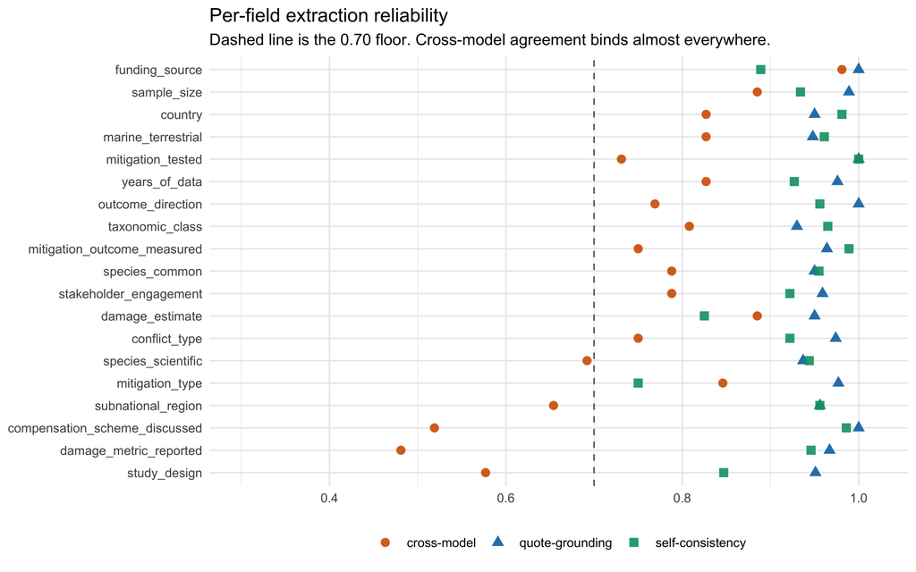

```r
p <- rel |>
  dplyr::select(field, grounding, self_consist, cross_model) |>
  tidyr::pivot_longer(-field, names_to = "measure", values_to = "value") |>
  dplyr::mutate(measure = dplyr::recode(measure, grounding = "quote-grounding",
                                        self_consist = "self-consistency",
                                        cross_model = "cross-model")) |>
  ggplot(aes(x = value, y = reorder(field, value), colour = measure, shape = measure)) +
  geom_vline(xintercept = FIELD_RELIABILITY_MIN, linetype = "dashed", colour = "grey40") +
  geom_point(size = 2.4, alpha = 0.9) +
  scale_colour_manual(values = OKABE[c(6, 5, 3)]) +
  scale_x_continuous(limits = c(0.3, 1.02)) +
  labs(x = NULL, y = NULL, colour = NULL, shape = NULL,
       title = "Per-field extraction reliability",
       subtitle = sprintf("Dashed line is the %.2f floor. Cross-model agreement binds almost everywhere.",
                          FIELD_RELIABILITY_MIN)) +
  theme_minimal(base_size = 10) + theme(legend.position = "bottom")
print(p)
```

```r
dir.create(here::here(DIR_FIGURES), showWarnings = FALSE, recursive = TRUE)
ggsave(here::here(DIR_FIGURES, "06_field_reliability.png"), p, width = 8, height = 5, dpi = 300)
ggsave(here::here(DIR_FIGURES, "06_field_reliability.svg"), p, width = 8, height = 5)
```

# 4 Why values ended up missing

```r
rs <- ext |> dplyr::filter(is_stated) |> dplyr::count(reason, sort = TRUE) |>
  dplyr::mutate(reason = tidyr::replace_na(reason, "kept"),
                pct = round(100 * n / sum(n), 2))
knitr::kable(rs, caption = "Disposition of every stated value")
```

Disposition of every stated value

| reason | n | pct |
| --- | --- | --- |
| kept | 2168 | 91.13 |
| inconsistent_extraction | 125 | 5.25 |
| unverified_quote | 86 | 3.61 |